# Data Visualization

Taylor Pearlman

December 2, 2015

This is the initial data cleaning/prepping and visualization step.

```r
#Loading the necessary packages
library(plyr)
library(dplyr)
```

```r
library(ggplot2)
library(knitr)
library(markdown)
library(stringr)
library(tidyr)
library(Amelia)
library(vcd)
library(corrgram)
library(Hmisc)
library(caret)
#Retrieving the data from the github repository
train.raw <- read.csv(url("https://raw.github.com/tapearlm/Predicting-Titanic-Passenger-Survival/master/train.csv"), na.strings = c("NA", ""))

#Changing variables to desired type
train.raw$Name <- as.character(train.raw$Name)
train.raw$Survived<- as.factor(train.raw$Survived)
train.raw$Pclass <- as.factor(train.raw$Pclass)
train.raw$PassengerId <- as.factor(train.raw$PassengerId)
```

I’ll start by looking at what data we have, and what data we’re missing. I’ll use the missmap function of the Amelia package to visualize this:

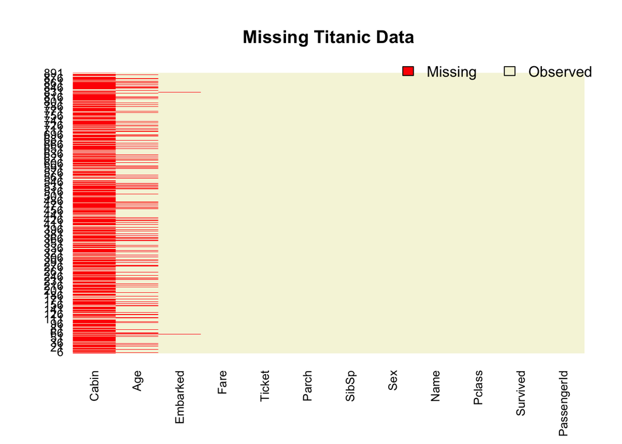

```r
missmap(train.raw, main = "Missing Titanic Data",
        col=c("red", "beige"), ylabels = NULL, y.at = NULL)
```

Most of the cabin information is missing, as well as a good deal of the age information. There probably won’t be enough cabin information to do anything useful with, but the age information will probably still prove useful. We’ll come back to this.

Next, we’ll use various methods in the ggplot and vcd packages to explore each variable.

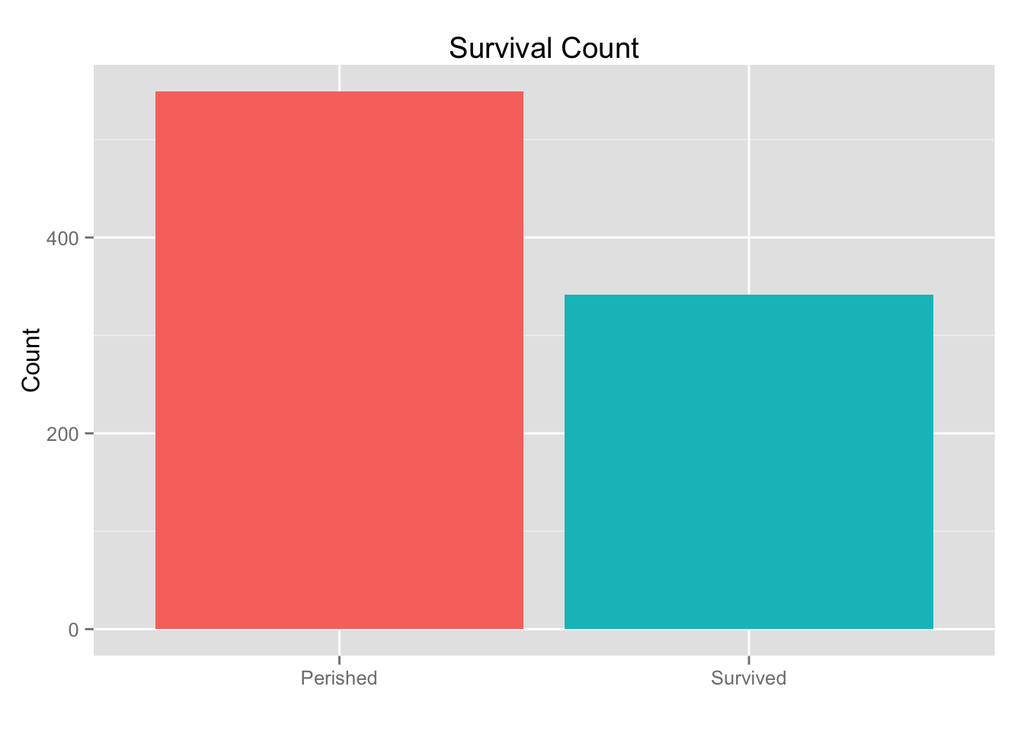

```r
train.raw%>%
  ggplot() + aes(Survived) + geom_bar(aes(fill = Survived))+ scale_x_discrete(labels = c("Perished", "Survived")) + theme(legend.position="none") + labs(title = "Survival Count", x = "", y = "Count")
```

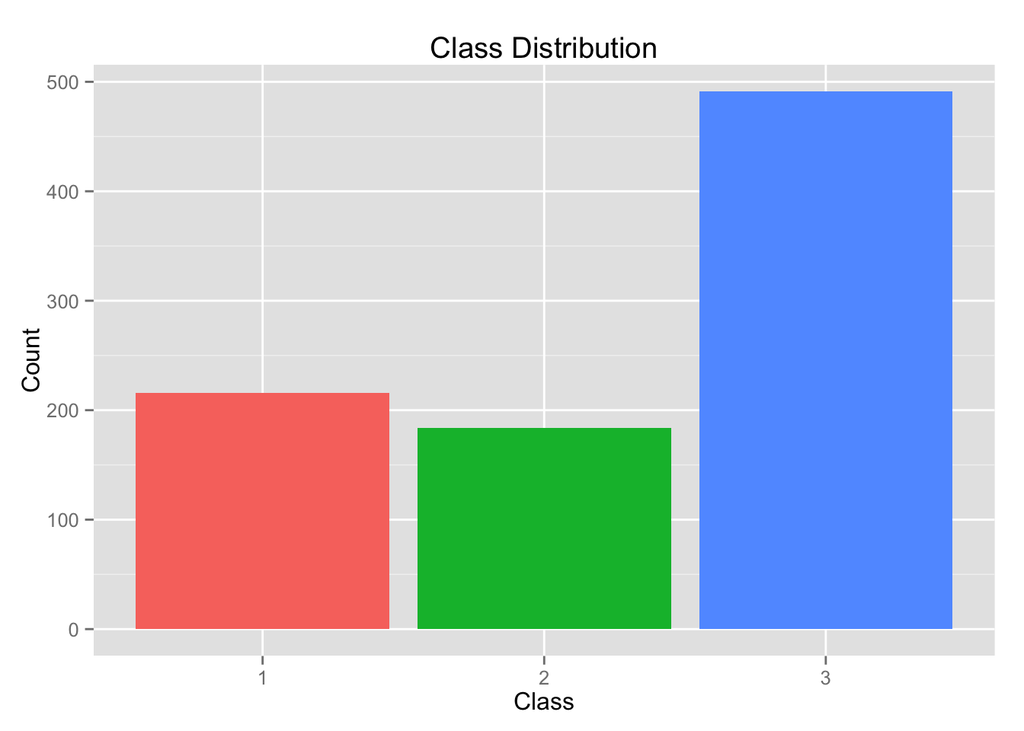

```r
train.raw%>%
  ggplot() + aes(Pclass) + geom_bar(aes(fill = Pclass))  + theme(legend.position="none") + labs(title = "Class Distribution", x = "Class", y = "Count")
```

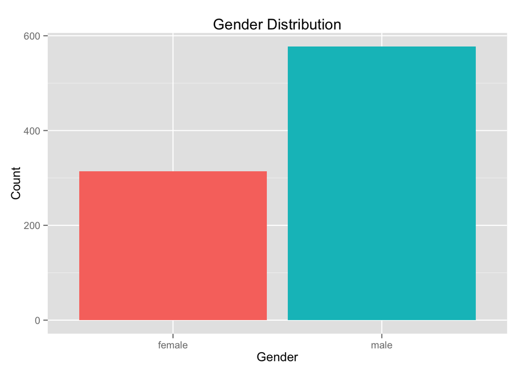

```r
train.raw%>%
  ggplot() + aes(Sex) + geom_bar(aes(fill = Sex))  + theme(legend.position="none") + labs(title = "Gender Distribution", x = "Gender", y = "Count")
```

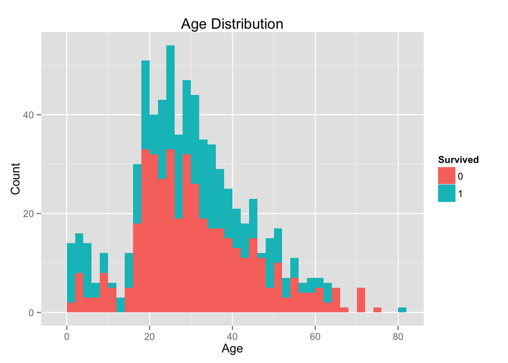

```r
train.raw%>%
  ggplot() + aes(Age) + geom_histogram(aes(fill = Survived), binwidth = 2) + labs(title = "Age Distribution", x = "Age", y = "Count")
```

[output not shown]

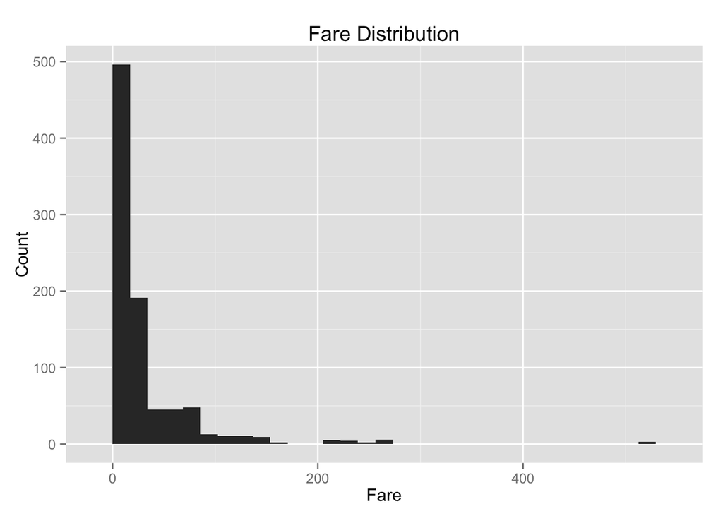

```r
train.raw%>%
  ggplot() + aes(Fare) + geom_histogram(aes(fill = Fare))  + theme(legend.position="none") + labs(title = "Fare Distribution", x = "Fare", y = "Count")
```

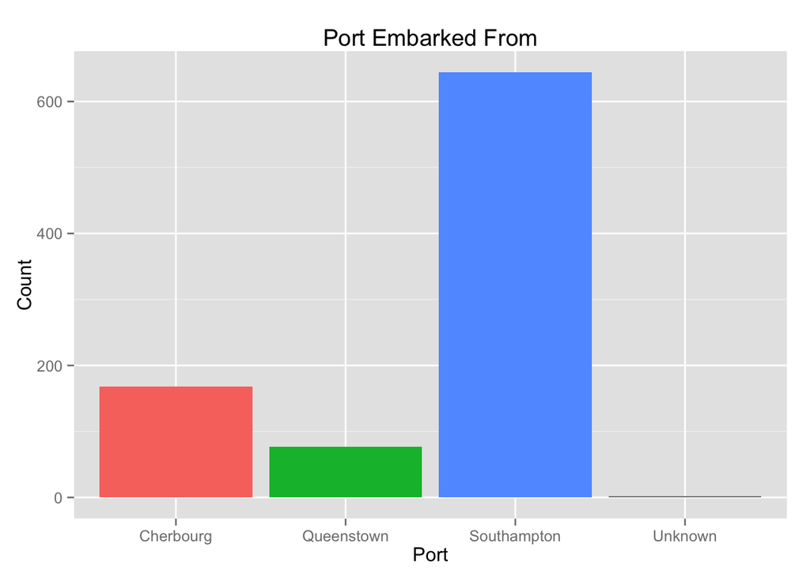

```r
train.raw%>%
  ggplot() + aes(Embarked) + geom_bar(aes(fill = Embarked))  + theme(legend.position="none") + labs(title = "Port Embarked From", x = "Port", y = "Count") + scale_x_discrete(labels = c("Cherbourg", "Queenstown", "Southampton", "Unknown"))
```

We can also use mosaic plots to visualize the basic relationships between the variables and survival rates:

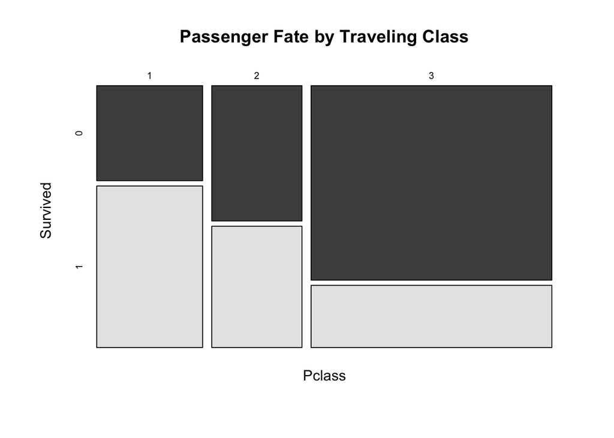

```r
mosaicplot(train.raw$Pclass ~ train.raw$Survived,
           main="Passenger Fate by Traveling Class", shade=FALSE,
           color=TRUE, xlab="Pclass", ylab="Survived")
```

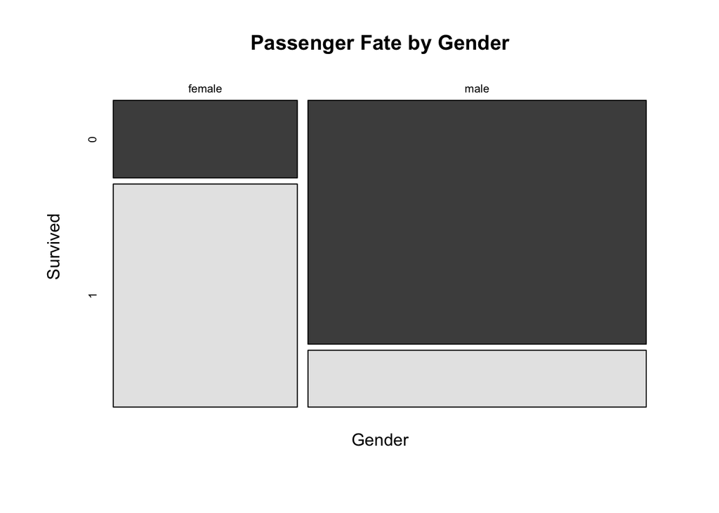

```r
mosaicplot(train.raw$Sex ~ train.raw$Survived,
           main="Passenger Fate by Gender", shade=FALSE, color=TRUE,
           xlab="Gender", ylab="Survived")
```

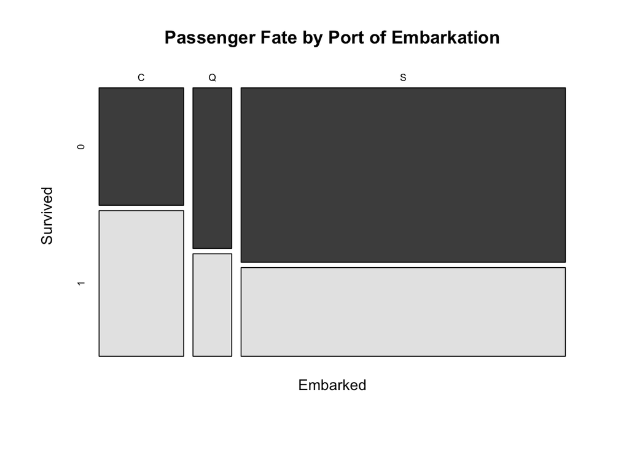

```r
mosaicplot(train.raw$Embarked ~ train.raw$Survived,
           main="Passenger Fate by Port of Embarkation",
           shade=FALSE, color=TRUE, xlab="Embarked", ylab="Survived")
```

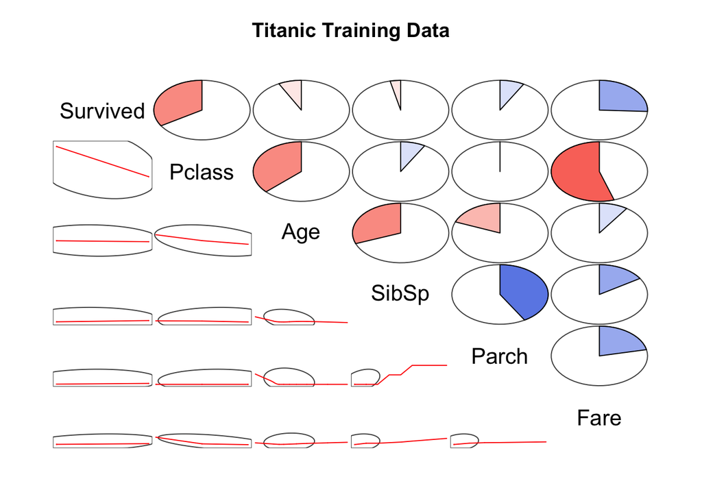

```r
corrgram.data <- train.raw

## change features of factor type to numeric type for inclusion on correlogram
corrgram.data$Survived <- as.numeric(corrgram.data$Survived)
corrgram.data$Pclass <- as.numeric(corrgram.data$Pclass)
corrgram.data$Embarked <- revalue(corrgram.data$Embarked, c("C" = 1, "Q" = 2, "S" = 3))

## generate correlogram
corrgram.vars <- c("Survived", "Pclass", "Sex", "Age",
                   "SibSp", "Parch", "Fare", "Embarked")
corrgram(corrgram.data[,corrgram.vars], order=FALSE,
         lower.panel=panel.ellipse, upper.panel=panel.pie,
         text.panel=panel.txt, main="Titanic Training Data")
```

```r
train.raw%>%
  select(Age)%>%
  summary()
```

```
##       Age
##  Min.   : 0.42
##  1st Qu.:20.12
##  Median :28.00
##  Mean   :29.70
##  3rd Qu.:38.00
##  Max.   :80.00
##  NA's   :177
```

That’s a lot of NA’s. We’ll try to fill the missing values in, with the method used by Curt Wehrley in his solution to this problem, found here: (https://github.com/wehrley/wehrley.github.io/blob/master/SOUPTONUTS.md)

The name information contains titles, which provide a decent indicator of age. We can strip the titles from the name field, and use the titles to estimate the missing age information.

```r
##Copying Curt Wehrley's code
## function for extracting honorific (i.e. title) from the Name feature
getTitle <- function(data) {
  title.dot.start <- regexpr("\\,[A-Z ]{1,20}\\.", data$Name, TRUE)
  title.comma.end <- title.dot.start + attr(title.dot.start, "match.length")-1
  data$Title <- substr(data$Name, title.dot.start+2, title.comma.end-1)
  return (data$Title)
}

train.raw$Title <- getTitle(train.raw)
unique(train.raw$Title)
```

```
##  [1] "Mr"           "Mrs"          "Miss"         "Master"
##  [5] "Don"          "Rev"          "Dr"           "Mme"
##  [9] "Ms"           "Major"        "Lady"         "Sir"
## [13] "Mlle"         "Col"          "Capt"         "the Countess"
## [17] "Jonkheer"
```

Let’s use the bystats function to see what values are missing:

```r
bystats(train.raw$Age, train.raw$Title)
```

```
##
##  Mean of train.raw$Age by
##
##                N Missing      Mean
## Capt           1       0 70.000000
## Col            2       0 58.000000
## Don            1       0 40.000000
## Dr             6       1 42.000000
## Jonkheer       1       0 38.000000
## Lady           1       0 48.000000
## Major          2       0 48.500000
## Master        36       4  4.574167
## Miss         146      36 21.773973
## Mlle           2       0 24.000000
## Mme            1       0 24.000000
## Mr           398     119 32.368090
## Mrs          108      17 35.898148
## Ms             1       0 28.000000
## Rev            6       0 43.166667
## Sir            1       0 49.000000
## the Countess   1       0 33.000000
## ALL          714     177 29.699118
```

```r
missingTitles <- c("Dr", "Master", "Mrs", "Miss", "Mr")
```

```r
getAge <- function(dat, title){
          medAge <- dat%>%
                    filter(Title == title)%>%
                    summarise(median(Age, na.rm = TRUE))%>%
                    as.numeric()
          return(medAge)
}


missingAgeData <- train.raw%>%
                  filter(Title %in% missingTitles)

for (i in 1:length(train.raw[[1]])){
  if (is.na(train.raw[i,]$Age)){
    train.raw[i,]$Age <- getAge(missingAgeData, train.raw[i,]$Title)
  }
}


train.raw$Embarked[which(is.na(train.raw$Embarked))] <- 'S'

getFare <- function(dat, class){
          medClass <- dat%>%
                      filter(Pclass == class)%>%
                      select(Fare)%>%
                      summarise(median(Fare, na.rm = TRUE))%>%
                      as.numeric()
          return(medClass)
}


## impute missings on Fare feature with median fare by Pclass
train.raw$Fare[ which(train.raw$Fare == 0 )] <- NA


for (i in 1:length(train.raw[[1]])){
  if (is.na(train.raw[i,]$Fare)){
    k <- train.raw[i,]
    train.raw[i,]$Fare <- getFare(train.raw, train.raw[i,]$Pclass)
  }
}
```

It also seems likely that the “protected members” (women and children) survived together, i.e. if little Billy made it into the lifeboat, his sister and mother likely did as well. To look at this, we need to strip out the family name from the name field, and make it it’s own variable.

“Protected Class” = Women and Passengers under 16

```r
getFamName <- function(data) {
  pattern <- regex("^(.+?),")
  data$FamName <- str_extract(data$Name, pattern)%>%
                  gsub(",", "", .)
  return(data$FamName)
}

train.raw$FamName <- getFamName(train.raw)

getfamSurvival <- function(passenger, data){

   if ((passenger$Age < 16) & (passenger$SibSp > 0)){
      string <- passenger$FamName

     sibData <- data%>%
                 filter((FamName %in% string) & (SibSp == passenger$SibSp))

      if(1 %in% sibData$Survived){
        famSurvival <- 1
      }
      else{
        famSurvival <- 0
      }
   }

  else if(identical(passenger$Sex, "female") & (passenger$Parch > 0)){
    string <- passenger$FamName
    childData <- data%>%
                  filter((Age <= 16) & (FamName %in% string) & (Parch <= passenger$Parch))

      if(1 %in% childData$Survived){
        famSurvival <- 1
      }
      else{
        famSurvival <- 0
      }

  }

  else{
    famSurvival <- 0
  }

  return(famSurvival)
}


train.raw <- train.raw%>%
             mutate(FamSurvival = 0)

for (i in 1:length(train.raw[[1]])){
  train.raw[i,]$FamSurvival <- getfamSurvival(train.raw[i,], train.raw)

}

train <- train.raw
remove(train.raw)
remove(missingAgeData)
```

Now for actually doing analysis. First, we’ll partition the data using the caret package:

```r
## split training data into train batch and test batch
set.seed(23)
training.rows <- createDataPartition(train$Survived,
                                     p = 0.8, list = FALSE)
train.batch <- train[training.rows, ]
test.batch <- train[-training.rows, ]
```

Basic logistic regression:

```r
Titanic.logit.1 <- glm(Survived ~ Sex + Pclass + Age + FamSurvival + Embarked,
                       data = train.batch, family=binomial("logit"))
Titanic.logit.1
```

```
##
## Call:  glm(formula = Survived ~ Sex + Pclass + Age + FamSurvival + Embarked,
##     family = binomial("logit"), data = train.batch)
##
## Coefficients:
## (Intercept)      Sexmale      Pclass2      Pclass3          Age
##     3.57422     -2.57253     -1.15725     -2.35626     -0.02251
## FamSurvival    EmbarkedQ    EmbarkedS
##     2.56949      0.10226     -0.61869
##
## Degrees of Freedom: 713 Total (i.e. Null);  706 Residual
## Null Deviance:       950.9
## Residual Deviance: 620.9     AIC: 636.9
```

```r
anova(Titanic.logit.1, test="Chisq")
```

```
## Analysis of Deviance Table
##
## Model: binomial, link: logit
##
## Response: Survived
##
## Terms added sequentially (first to last)
##
##
##             Df Deviance Resid. Df Resid. Dev  Pr(>Chi)
## NULL                          713     950.86
## Sex          1  202.688       712     748.18 < 2.2e-16 ***
## Pclass       2   76.110       710     672.07 < 2.2e-16 ***
## Age          1   23.707       709     648.36 1.122e-06 ***
## FamSurvival  1   19.060       708     629.30 1.267e-05 ***
## Embarked     2    8.433       706     620.87   0.01475 *
## ---
## Signif. codes:  0 '***' 0.001 '**' 0.01 '*' 0.05 '.' 0.1 ' ' 1
```